# DYOM Assignment 2: Option 1

Building and Deploying a CNN Classifier almost from scratch In this assignment, i will be using the Flickr Style Dataset, reduced to 10 classes and 500 images of each class, reduced to 320 x 320 px. First, importing all relevant libraries and modules

```python
from tensorflow.keras.applications.resnet50 import ResNet50, preprocess_input
import tensorflow.keras as keras
from tensorflow.keras import models
from tensorflow.keras import layers
from tensorflow.keras import optimizers
import tensorflow as tf
from keras.utils import np_utils
from tensorflow.keras.models import load_model
from tensorflow.keras.preprocessing import image
import numpy as np
import matplotlib.pyplot as plt
from PIL import Image
import cv2
import random
from sklearn.metrics import plot_confusion_matrix
from tensorflow.keras.models import model_from_json
from matplotlib import pyplot
from keras.preprocessing.image import load_img
from keras.preprocessing.image import img_to_array
from keras.preprocessing.image import array_to_img
from io import BytesIO
from skimage.transform import resize
from keras.preprocessing.image import ImageDataGenerator
```

# Tuning of Hyperparameters set for training model.

Will be used later, may be freely changed but best version of the model is set when batch size = 32 and learning rate is set to 2e-5 while number of epochs=10.

```python
###Hyperparameter tuning
BATCH_SIZE = 32
EPOCHS = 10
LEARNING_RATE = 2e-5
```

# Importing and Preprocessing Dataset

Leveraging on keras API, ImageDataGenerator was loaded before using flow_from_directory that is used to import the dataset. flow_from_directory works when Dataset folder is split into Train and Test folder with 10 subfolders within each folder. After importing the data, it is split into batches of size 32 as confirmed with the print statement.

## Legend

*batchX* = training images converted to numpy arrays, *batchy* = training labels in binary format of [0. 0. 1. 0. 0. 0. 0. 0. 0. 0.] format, *testX* = test images converted to numpy arrays, *testy* = test labels in binary format.

So batchX[0] is the image which corresponds to batchy[0] which is the label.

*class_names* are copied from Flickr Style Dataset, only the first 10 classes were used, with the replacement of "Bright" with "Romance" because of some faulty data.

```python
# create generator
datagen = ImageDataGenerator(rescale=1./255)

#Initialize class names from Flickr Style Dataset
class_names = ["Bokeh","Romance","Depth of Field","Detailed","Ethereal","Geometric Composition","Hazy","HDR","Horror","Long Exposure"]

# prepare an iterators for each dataset
train_it = datagen.flow_from_directory('/content/drive/My Drive/Data/Train',target_size=(320,320), class_mode='categorical', batch_size=BATCH_SIZE, interpolation = 'nearest')
test_it = datagen.flow_from_directory('/content/drive/My Drive/Data/Test',target_size=(320,320), class_mode='categorical',batch_size= BATCH_SIZE, interpolation = 'nearest')
# confirm the iterator works
batchX, batchy = train_it.next()
testX, testy = test_it.next()
print('Batch shape=%s, min=%.3f, max=%.3f' % (batchX.shape, batchX.min(), batchX.max()))
print(testX.shape)
print(batchy[1])
```

```
Found 4010 images belonging to 10 classes.
Found 991 images belonging to 10 classes.
Batch shape=(32, 320, 320, 3), min=0.000, max=1.000
(32, 320, 320, 3)
[0. 0. 1. 0. 0. 0. 0. 0. 0. 0.]
```

Plotting a random image from the first instance of batchX just to confirm the data is loaded properly and all looks good.

[figure not shown]

```python
rand = random.randint(0,32)
plt.imshow(batchX[rand])
plt.xlabel(class_names[np.argmax(batchy[rand])])
```

# Convolutional Neural Network

Importing convolutional base from ResNet50 whose weights were trained on ImageNet. Removing the top classifier layer to suit our dataset. Input shape was also adjusted to suit our dataset.

```python
conv_base = ResNet50(weights='imagenet', include_top=False, input_shape=(320,320,3))
```

```
Downloading data from https://storage.googleapis.com/tensorflow/keras-applications/resnet/resnet50_weights_tf_dim_ordering_tf_kernels_notop.h5
```

**Model archictecture**

These factors seem to give the best accuracy and optimal loss. Note that this is the result after training 10 different models hosted on Google Colabs. Also note that each model takes long to train with the exception of 4-5am for some reason which takes only minutes compared to hours.

```python
STEP_SIZE_TRAIN=train_it.n//train_it.batch_size
STEP_SIZE_TEST=test_it.n//test_it.batch_size

model = models.Sequential()
#model.add(layers.UpSampling2D((2,2)))
#model.add(layers.UpSampling2D((2,2)))
#model.add(layers.UpSampling2D((2,2)))
model.add(conv_base)
model.add(layers.Flatten())
model.add(layers.BatchNormalization())
model.add(layers.Dense(128, activation='relu'))
model.add(layers.Dropout(0.5))
model.add(layers.BatchNormalization())
model.add(layers.Dense(64, activation='relu'))
model.add(layers.Dropout(0.5))
model.add(layers.BatchNormalization())
#model.add(layers.Dense(64, activation='relu')) ##These may be uncommented to add more layers to CNN
#model.add(layers.Dropout(0.5)) ##These may be uncommented to add more layers to CNN
#model.add(layers.BatchNormalization()) ##These may be uncommented to add more layers to CNN
model.add(layers.Dense(10, activation='softmax'))

model.compile(optimizer=optimizers.RMSprop(lr=LEARNING_RATE), loss='binary_crossentropy', metrics=['acc'])

history = model.fit_generator(generator=train_it,
                    steps_per_epoch=STEP_SIZE_TRAIN,
                    validation_data=test_it,
                    validation_steps=STEP_SIZE_TEST,
                    epochs=EPOCHS)
```

```
WARNING:tensorflow:From <ipython-input-7-1fdd6b86e766>:28: Model.fit_generator (from tensorflow.python.keras.engine.training) is deprecated and will be removed in a future version.
Instructions for updating:
Please use Model.fit, which supports generators.
```

**Saving Model to Drive**

Writing the model to a JSON file before saving the Model Weights as a HDF5 file to mounted drive on google colabs

```python
#save model weights to drive
model_json = model.to_json()
with open('model.json', 'w') as json_file:
    json_file.write(model_json)
model.save_weights('/content/drive/My Drive/model.h5')
```

**Displaying Model Architecture**

```python
model.summary()
```

```
Model: "sequential"
_________________________________________________________________
Layer (type)                 Output Shape              Param #
=================================================================
resnet50 (Model)             (None, 10, 10, 2048)      23587712
_________________________________________________________________
flatten (Flatten)            (None, 204800)            0
_________________________________________________________________
batch_normalization (BatchNo (None, 204800)            819200
_________________________________________________________________
dense (Dense)                (None, 128)               26214528
_________________________________________________________________
dropout (Dropout)            (None, 128)               0
_________________________________________________________________
batch_normalization_1 (Batch (None, 128)               512
_________________________________________________________________
dense_1 (Dense)              (None, 64)                8256
_________________________________________________________________
dropout_1 (Dropout)          (None, 64)                0
_________________________________________________________________
batch_normalization_2 (Batch (None, 64)                256
_________________________________________________________________
dense_2 (Dense)              (None, 10)                650
=================================================================
Total params: 50,631,114
Trainable params: 50,168,010
Non-trainable params: 463,104
_________________________________________________________________
```

# Evaulating Model

Using model.evaluate on the test dataset, the loss and accuracy on the test dataset is returned.

```python
model.evaluate_generator(generator=test_it,
steps=STEP_SIZE_TEST)
```

```
[0.2092977613210678, 0.589155375957489]
```

**Plotting Training and Validation Loss and Accuracy against epochs**

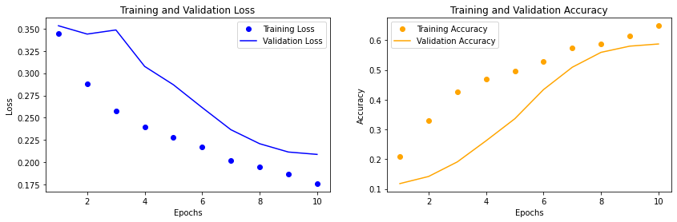

```python
history_dict = history.history
loss_values = history_dict['loss']
val_loss_values = history_dict['val_loss']

epochs = range(1, len(loss_values) + 1)

plt.figure(figsize=(14, 4))

plt.subplot(1,2,1)
plt.plot(epochs, loss_values, 'bo', label='Training Loss')
plt.plot(epochs, val_loss_values, 'b', label='Validation Loss')
plt.title('Training and Validation Loss')
plt.xlabel('Epochs')
plt.ylabel('Loss')
plt.legend()

acc = history_dict['acc']
val_acc = history_dict['val_acc']

epochs = range(1, len(loss_values) + 1)

plt.subplot(1,2,2)
plt.plot(epochs, acc, 'bo', label='Training Accuracy', c='orange')
plt.plot(epochs, val_acc, 'b', label='Validation Accuracy', c='orange')
plt.title('Training and Validation Accuracy')
plt.xlabel('Epochs')
plt.ylabel('Accuracy')
plt.legend()
```

**Testing Model Prediction**

Plotting a number of images with the correct labels to see if model can accurately predict the correct labels within one batch of test images.

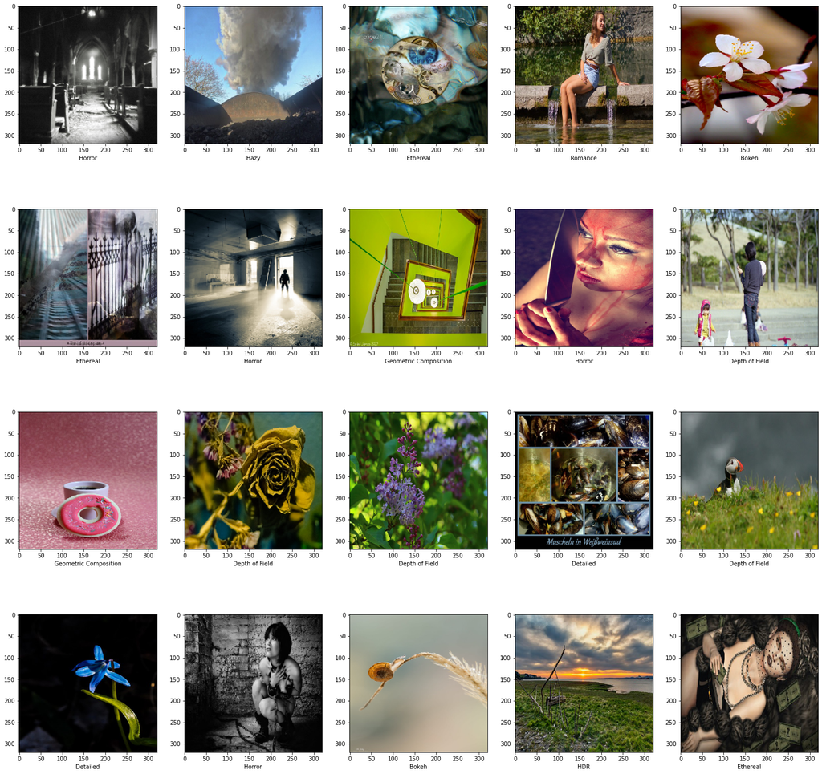

```python
num_images = 20 #Change this to display more images in multiples of 5
#train_it.reset()
#test_it.reset()
plt.figure(figsize=(25,25))
for i in range(num_images):
    plt.subplot(num_images/5,5,i+1)
    #plt.xticks([])
    #plt.yticks([])
    plt.grid(False)
    plt.imshow(testX[i], cmap=plt.cm.binary) #Change this from test to train
    plt.xlabel(class_names[np.argmax(testy[i])]) #Change this from test to train
plt.show()
```

Loading trained CNN model with the JSON and h5 file

Using Model to predict the labels for the number of images displayed above

```python
# Load trained CNN model
json_file = open('model.json', 'r')
loaded_model_json = json_file.read()
json_file.close()
model = model_from_json(loaded_model_json)
model.load_weights('/content/drive/My Drive/model.h5')

indices = np.argmax(model.predict_on_batch(testX[:num_images]),1) #Change this from test to train but use x_train or x_test
print("Predicted labels for test images displayed above:")
print([class_names[x] for x in indices])

lst1 = []
a= 0

for i in range(num_images):
  lst1.append(class_names[np.argmax(testy[i])])  #Change this from test to train
lst2 = [class_names[x] for x in indices]

for i in range(num_images):
  if lst2[i] == lst1[i]:
    a+=1
  else: continue
print("CNN Model can predict", a ,"correctly out of", num_images ,"test images.")
```

```
Predicted labels for test images displayed above:
['Horror', 'Hazy', 'Bokeh', 'Romance', 'Bokeh', 'Geometric Composition', 'Horror', 'Geometric Composition', 'Horror', 'Romance', 'Geometric Composition', 'Detailed', 'Depth of Field', 'HDR', 'Bokeh', 'Detailed', 'Horror', 'Bokeh', 'HDR', 'Romance']
CNN Model can predict 13 correctly out of 20 test images.
```

**Top K Predictions**

Plotting a random image from the batch displayed above and plotting the top k predictions and probabilities

[figure not shown]

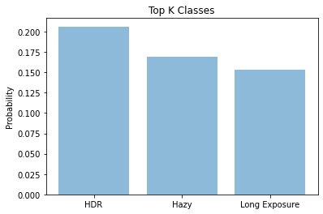

```python
top_k = 3 #Change this value for more k
n = random.randint(0,BATCH_SIZE) #Change this number to display any of the above nth images
lst = []
idx = []

top_values, top_indices = tf.nn.top_k(model.predict_on_batch(testX[n-1:n]), k=top_k)

plt.imshow(testX[n], cmap=plt.cm.binary) #Change this from test to train
plt.xlabel(class_names[np.argmax(testy[n])])
plt.show()

for i in range(0,top_k):
  lst.append(class_names[top_indices.numpy()[0][i]])
  idx.append(top_values.numpy()[0][i])


objects = tuple(lst)
y_pos = np.arange(len(objects))
performance = idx
plt.bar(y_pos, performance, align='center', alpha=0.5)
plt.xticks(y_pos, objects)
plt.ylabel('Probability')
plt.title('Top K Classes')
plt.show()
```

# Predicting Image from File Path

Reading an image from specified file path based on mounted google drive.

In this example, i have specified an image belonging to "Horror" to see if the model can predict labels based on data it has never seen.

Plotting the image.

[figure not shown]

```python
path = '/content/drive/My Drive/horror1.jpg' ##Change this for image path
image = tf.keras.preprocessing.image.load_img(
    path, grayscale=False, color_mode='rgb', target_size=(320,320),
    interpolation='nearest')
plt.imshow(image)
```

Plotting Top K predictions and probabilities based on Image displayed above.

```
Predicted class for uploaded image is: ['Horror']
```

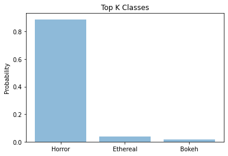

```python
array = tf.keras.preprocessing.image.img_to_array(image, data_format=None, dtype=None)
array /= 255
array = np.resize(array,(1,320,320,3))

top_k = 3 #Change to display more K classes

lst1=[]
lst2=[]

pred = np.argmax(model.predict_on_batch(array[0:1]),1)
print("Predicted class for uploaded image is:",str([class_names[x] for x in pred]))

top_values, top_indices = tf.nn.top_k(model.predict_on_batch(array[0:1]), k=top_k)

for i in range(0,top_k):
  lst1.append(class_names[top_indices.numpy()[0][i]])
  lst2.append(top_values.numpy()[0][i])


objects = tuple(lst1)
y_pos = np.arange(len(objects))
performance = lst2
plt.bar(y_pos, performance, align='center', alpha=0.5)
plt.xticks(y_pos, objects)
plt.ylabel('Probability')
plt.title('Top K Classes')
plt.show()
```